# JHU Data Science Course 8 - Machine Learning Assignment

## Background

Using devices such as Jawbone Up, Nike FuelBand, and Fitbit it is now possible to collect a large amount of data about personal activity relatively inexpensively. These type of devices are part of the quantified self movement.

One thing that people regularly do is quantify how much of a particular activity they do, but they rarely quantify how well they do it. In this project, the goal will be to use data from accelerometers on the belt, forearm, arm, and dumbell of 6 participants. They were asked to perform barbell lifts correctly and incorrectly in 5 different ways.

Summarizing from the website http://groupware.les.inf.puc-rio.br/har :

Six young health participants were asked to perform one set of 10 repetitions of the Unilateral Dumbbell Biceps Curl in five different fashions: exactly according to the specification (Class A), throwing the elbows to the front (Class B), lifting the dumbbell only halfway (Class C), lowering the dumbbell only halfway (Class D) and throwing the hips to the front (Class E).

Thus, Class A corresponds to the specified execution of the exercise, while the other 4 classes correspond to common mistakes.

## Exploratory Data Analysis

Let’s take a look at the provided training and testing data. We see that the data consists of 19,622 observations of 160 variables. In particular, the distribution of the CLASSE variable is shown.

```r
options( warn = -1 )
library(ggplot2)
library(caret)
library(randomForest)
setwd("C:/Data Analytics/Coursera - Data Science (JHU)/Course 8/Project")

training_data <- read.csv("pml-training.csv", stringsAsFactors = FALSE )

str( training_data, list.len = 20 )
```

```
## 'data.frame':    19622 obs. of  160 variables:
##  $ X                       : int  1 2 3 4 5 6 7 8 9 10 ...
##  $ user_name               : chr  "carlitos" "carlitos" "carlitos" "carlitos" ...
##  $ raw_timestamp_part_1    : int  1323084231 1323084231 1323084231 1323084232 1323084232 1323084232 1323084232 1323084232 1323084232 1323084232 ...
##  $ raw_timestamp_part_2    : int  788290 808298 820366 120339 196328 304277 368296 440390 484323 484434 ...
##  $ cvtd_timestamp          : chr  "5/12/2011 11:23" "5/12/2011 11:23" "5/12/2011 11:23" "5/12/2011 11:23" ...
##  $ new_window              : chr  "no" "no" "no" "no" ...
##  $ num_window              : int  11 11 11 12 12 12 12 12 12 12 ...
##  $ roll_belt               : num  1.41 1.41 1.42 1.48 1.48 1.45 1.42 1.42 1.43 1.45 ...
##  $ pitch_belt              : num  8.07 8.07 8.07 8.05 8.07 8.06 8.09 8.13 8.16 8.17 ...
##  $ yaw_belt                : num  -94.4 -94.4 -94.4 -94.4 -94.4 -94.4 -94.4 -94.4 -94.4 -94.4 ...
##  $ total_accel_belt        : int  3 3 3 3 3 3 3 3 3 3 ...
##  $ kurtosis_roll_belt      : chr  "" "" "" "" ...
##  $ kurtosis_picth_belt     : chr  "" "" "" "" ...
##  $ kurtosis_yaw_belt       : chr  "" "" "" "" ...
##  $ skewness_roll_belt      : chr  "" "" "" "" ...
##  $ skewness_roll_belt.1    : chr  "" "" "" "" ...
##  $ skewness_yaw_belt       : chr  "" "" "" "" ...
##  $ max_roll_belt           : num  NA NA NA NA NA NA NA NA NA NA ...
##  $ max_picth_belt          : int  NA NA NA NA NA NA NA NA NA NA ...
##  $ max_yaw_belt            : chr  "" "" "" "" ...
##   [list output truncated]
```

```r
table( training_data$classe )
```

```
##
##    A    B    C    D    E
## 5580 3797 3422 3216 3607
```

```r
sum( table( training_data$classe ) )
```

```
## [1] 19622
```

## Data Pre-processing: Cleaning & Formatting

Before doing any modeling, we can discard the first 6 informational columns and the last one, which contains the CLASSE variable. After converting any CHAR in the remaining data to NUMERIC, we convert the resulting MATRIX to a DATA FRAME, and convert any NA to 0, and finally attach the saved CLASSE column as CHAR.

```r
classe <- training_data$classe
training_data <- as.data.frame( sapply( training_data[,7:159], as.numeric ))
training_data[ is.na(training_data) ] <- 0L
training_data <- cbind( training_data, classe )
```

Next, we split the training data into two partitions, choosing 75% to train and 25% to test. This allows an out-of-sample error to be estimated. (Note that we are saving the actual 20-sample test data for later use.)

```r
inTrain  <- createDataPartition( y = training_data$classe, p = 0.75, list = FALSE )
trainClasse <- training_data[ inTrain, ]
testClasse  <- training_data[-inTrain, ]

dim(trainClasse)
```

```
## [1] 14718   154
```

```r
dim(testClasse)
```

```
## [1] 4904  154
```

```r
str( trainClasse, list.len = 40 )
```

```
## 'data.frame':    14718 obs. of  154 variables:
##  $ num_window              : num  11 11 12 12 12 12 12 12 12 12 ...
##  $ roll_belt               : num  1.41 1.42 1.48 1.48 1.45 1.42 1.42 1.43 1.45 1.45 ...
##  $ pitch_belt              : num  8.07 8.07 8.05 8.07 8.06 8.09 8.13 8.16 8.17 8.18 ...
##  $ yaw_belt                : num  -94.4 -94.4 -94.4 -94.4 -94.4 -94.4 -94.4 -94.4 -94.4 -94.4 ...
##  $ total_accel_belt        : num  3 3 3 3 3 3 3 3 3 3 ...
##  $ kurtosis_roll_belt      : num  0 0 0 0 0 0 0 0 0 0 ...
##  $ kurtosis_picth_belt     : num  0 0 0 0 0 0 0 0 0 0 ...
##  $ kurtosis_yaw_belt       : num  0 0 0 0 0 0 0 0 0 0 ...
##  $ skewness_roll_belt      : num  0 0 0 0 0 0 0 0 0 0 ...
##  $ skewness_roll_belt.1    : num  0 0 0 0 0 0 0 0 0 0 ...
##  $ skewness_yaw_belt       : num  0 0 0 0 0 0 0 0 0 0 ...
##  $ max_roll_belt           : num  0 0 0 0 0 0 0 0 0 0 ...
##  $ max_picth_belt          : num  0 0 0 0 0 0 0 0 0 0 ...
##  $ max_yaw_belt            : num  0 0 0 0 0 0 0 0 0 0 ...
```

[output cut: 27 more lines]

## Classification & Cross-Validation

The Random Forest classification algorithm for decision trees can now be performed. This algorithm is known to be generally proficient at avoiding the over-fitting of data. The resulting confusion matrix and Gini plot are shown.

```r
mrf <- randomForest( trainClasse$classe ~ ., data = trainClasse )
print( mrf )
```

```
##
## Call:
##  randomForest(formula = trainClasse$classe ~ ., data = trainClasse)
##                Type of random forest: classification
##                      Number of trees: 500
## No. of variables tried at each split: 12
##
##         OOB estimate of  error rate: 0.27%
## Confusion matrix:
##      A    B    C    D    E  class.error
## A 4185    0    0    0    0 0.0000000000
## B    6 2841    1    0    0 0.0024578652
## C    0   10 2557    0    0 0.0038955980
## D    0    0   19 2391    2 0.0087064677
## E    0    0    0    2 2704 0.0007390983
```

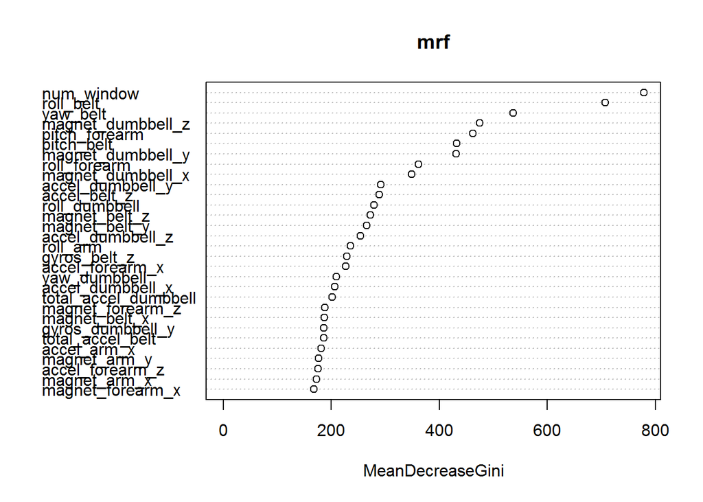

```r
varImpPlot( mrf )
```

```r
mrf_cv <- train( classe ~ num_window + roll_belt + yaw_belt + magnet_dumbbell_z + pitch_forearm
            + magnet_dumbbell_y + pitch_belt + roll_forearm + magnet_dumbbell_x + accel_belt_z,
            data = trainClasse, method = "rf", trControl = trainControl(method = "cv", number = 5) )
print( mrf_cv, digits = 5 )
```

```
## Random Forest
##
## 14718 samples
##    10 predictor
##     5 classes: 'A', 'B', 'C', 'D', 'E'
##
## No pre-processing
## Resampling: Cross-Validated (5 fold)
## Summary of sample sizes: 11773, 11775, 11776, 11774, 11774
## Resampling results across tuning parameters:
##
##   mtry  Accuracy  Kappa
##    2    0.99742   0.99673
##    6    0.99830   0.99785
##   10    0.99762   0.99699
##
## Accuracy was used to select the optimal model using the largest value.
## The final value used for the model was mtry = 6.
```

```r
mrf_pred <- predict( mrf_cv, newdata = testClasse )
mrf_CM   <- confusionMatrix( mrf_pred, testClasse$classe )

table( mrf_pred )
```

```
## mrf_pred
##    A    B    C    D    E
## 1396  952  855  806  895
```

```r
sum( table( mrf_pred ))
```

```
## [1] 4904
```

```r
mrf_CM$table
```

```
##           Reference
## Prediction    A    B    C    D    E
##          A 1395    1    0    0    0
##          B    0  948    1    0    3
##          C    0    0  854    1    0
##          D    0    0    0  803    3
##          E    0    0    0    0  895
```

```r
prop.table( mrf_CM$table )
```

```
##           Reference
## Prediction            A            B            C            D
##          A 0.2844616639 0.0002039152 0.0000000000 0.0000000000
##          B 0.0000000000 0.1933115824 0.0002039152 0.0000000000
##          C 0.0000000000 0.0000000000 0.1741435563 0.0002039152
##          D 0.0000000000 0.0000000000 0.0000000000 0.1637438825
##          E 0.0000000000 0.0000000000 0.0000000000 0.0000000000
##           Reference
## Prediction            E
##          A 0.0000000000
##          B 0.0006117455
##          C 0.0000000000
##          D 0.0006117455
##          E 0.1825040783
```

```r
mrf_CM$overall[1]
```

```
##  Accuracy
## 0.9981648
```

## Predictions on Test Data

Applying our final model to the 20-sample test data (after first pre-processing the test data in the same manner as for the original training data) gives the following table for the CLASSE predction:

```r
setwd("C:/Data Analytics/Coursera - Data Science (JHU)/Course 8/Project")
testing_data  <- read.csv("pml-testing.csv" , stringsAsFactors = FALSE )
pid <- testing_data$problem_id
testing_data <- as.data.frame( sapply( testing_data[,7:159], as.numeric ))
testing_data[ is.na(testing_data) ] <- 0L
testing_data <- cbind( testing_data, pid )

predictions_20 <- predict( mrf_cv, newdata = testing_data )
data.frame( pid, predictions_20 )
```

```
##    pid predictions_20
## 1    1              B
## 2    2              A
## 3    3              B
## 4    4              A
## 5    5              A
## 6    6              E
## 7    7              D
## 8    8              B
## 9    9              A
## 10  10              A
## 11  11              B
## 12  12              C
## 13  13              B
## 14  14              A
## 15  15              E
## 16  16              E
## 17  17              A
## 18  18              B
## 19  19              B
## 20  20              B
```